# Analysis of McDonald’s Menu

Creator: *Christian Cruz*

*“Introduction”*

The McDonald fast food restaurant is the most popular fast food worldwide as it receives customers on the daily and people widly enjoy their food while eating in their restaurants. Although, most people don’t really take notice in the nutritious facts of what they eat. They eat at McDonald’s for the enjoyment of the food but not for the contents within it.

Loading Packages

```r
library (tidyverse)
```

```r
library (dplyr)
library (ggplot2)
```

```r
mc_menu <- read.csv(file = "https://raw.githubusercontent.com/Christian10951/datasets/master/macmenu.csv")
```

```r
head(mc_menu)
```

```
##    Category                             Item   Serving.Size Calories
## 1 Breakfast                     Egg McMuffin 4.8 oz (136 g)      300
## 2 Breakfast                Egg White Delight 4.8 oz (135 g)      250
## 3 Breakfast                 Sausage McMuffin 3.9 oz (111 g)      370
## 4 Breakfast        Sausage McMuffin with Egg 5.7 oz (161 g)      450
## 5 Breakfast Sausage McMuffin with Egg Whites 5.7 oz (161 g)      400
## 6 Breakfast             Steak & Egg McMuffin 6.5 oz (185 g)      430
##   Calories.from.Fat Total.Fat Total.Fat....Daily.Value. Saturated.Fat
## 1               120        13                        20             5
## 2                70         8                        12             3
## 3               200        23                        35             8
## 4               250        28                        43            10
## 5               210        23                        35             8
## 6               210        23                        36             9
##   Saturated.Fat....Daily.Value. Trans.Fat Cholesterol
```

[output cut: 34 more lines]

Numbers of Rows/Columns

```r
dim(mc_menu)
```

```
## [1] 260  24
```

Column Names

```r
colnames(mc_menu)
```

```
##  [1] "Category"                      "Item"
##  [3] "Serving.Size"                  "Calories"
##  [5] "Calories.from.Fat"             "Total.Fat"
##  [7] "Total.Fat....Daily.Value."     "Saturated.Fat"
##  [9] "Saturated.Fat....Daily.Value." "Trans.Fat"
## [11] "Cholesterol"                   "Cholesterol....Daily.Value."
## [13] "Sodium"                        "Sodium....Daily.Value."
## [15] "Carbohydrates"                 "Carbohydrates....Daily.Value."
## [17] "Dietary.Fiber"                 "Dietary.Fiber....Daily.Value."
## [19] "Sugars"                        "Protein"
## [21] "Vitamin.A....Daily.Value."     "Vitamin.C....Daily.Value."
## [23] "Calcium....Daily.Value."       "Iron....Daily.Value."
```

*“Problem #1: Which item has the highest number of calories?”*

```r
Highest_Calories <- mc_menu %>%
  group_by(Calories, Item) %>%
  filter(Calories > 0) %>%
  summarise(num_Calories = n()) %>%
  filter(num_Calories == max(num_Calories)) %>%
  select(Item, Calories)
Highest_Calories
```

```
## # A tibble: 244 x 2
## # Groups:   Calories [77]
##    Item                                                     Calories
##    <chr>                                                       <int>
##  1 Apple Slices                                                   15
##  2 Side Salad                                                     20
##  3 Kids Ice Cream Cone                                            45
##  4 Iced Coffee with Sugar Free French Vanilla Syrup (Small)       80
##  5 Minute Maid 100% Apple Juice Box                               80
##  6 1% Low Fat Milk Jug                                           100
##  7 Coca-Cola Classic (Child)                                     100
##  8 Dr Pepper (Child)                                             100
##  9 Nonfat Latte (Small)                                          100
## 10 Sprite (Child)                                                100
## # ... with 234 more rows
```

```r
Highest_Calories <- mc_menu %>%
  group_by(Calories, Item) %>%
  filter(Calories == 1880) %>%
  summarise(num_Calories = n()) %>%
  filter(num_Calories == max(num_Calories)) %>%
  select(Item, Calories)
Highest_Calories
```

```
## # A tibble: 1 x 2
## # Groups:   Calories [1]
##   Item                         Calories
##   <chr>                           <int>
## 1 Chicken McNuggets (40 piece)     1880
```

*“Problem #2: Which item has the lowest serving size?”*

```r
Lowest_Serving.Size <- mc_menu %>%
  group_by(Item, Serving.Size) %>%
  filter(Serving.Size > 0) %>%
  summarise(num_Serving.Size = n()) %>%
  filter(num_Serving.Size == min(num_Serving.Size)) %>%
  select(Item, Serving.Size)
Lowest_Serving.Size
```

```
## # A tibble: 260 x 2
## # Groups:   Item [260]
##    Item                                      Serving.Size
##    <chr>                                     <chr>
##  1 1% Low Fat Milk Jug                       1 carton (236 ml)
##  2 Apple Slices                              1.2 oz (34 g)
##  3 Bacon Buffalo Ranch McChicken             5.7 oz (161 g)
##  4 Bacon Cheddar McChicken                   6 oz (171 g)
##  5 Bacon Clubhouse Burger                    9.5 oz (270 g)
##  6 Bacon Clubhouse Crispy Chicken Sandwich   10 oz (284 g)
##  7 Bacon Clubhouse Grilled Chicken Sandwich  9.5 oz (270 g)
##  8 Bacon McDouble                            5.7 oz (161 g)
##  9 Bacon, Egg & Cheese Bagel                 6.9 oz (197 g)
## 10 Bacon, Egg & Cheese Bagel with Egg Whites 7.1 oz (201 g)
## # ... with 250 more rows
```

```r
Lowest_Serving.Size <- mc_menu %>%
  group_by(Item, Serving.Size) %>%
  filter(Serving.Size == "12 fl oz cup") %>%
  summarise(num_Serving.Size = n()) %>%
  filter(num_Serving.Size == min(num_Serving.Size)) %>%
  select(Item, Serving.Size)
Lowest_Serving.Size
```

```
## # A tibble: 38 x 2
## # Groups:   Item [38]
##    Item                                   Serving.Size
##    <chr>                                  <chr>
##  1 Blueberry Pomegranate Smoothie (Small) 12 fl oz cup
##  2 Caramel Latte (Small)                  12 fl oz cup
##  3 Caramel Mocha (Small)                  12 fl oz cup
##  4 Chocolate Shake (Small)                12 fl oz cup
##  5 Coca-Cola Classic (Child)              12 fl oz cup
##  6 Coffee (Small)                         12 fl oz cup
##  7 Diet Coke (Child)                      12 fl oz cup
##  8 Diet Dr Pepper (Child)                 12 fl oz cup
##  9 Dr Pepper (Child)                      12 fl oz cup
## 10 FrappÃ© Caramel (Small)                12 fl oz cup
## # ... with 28 more rows
```

```r
Category_most_items <- mc_menu %>%
  group_by(Category, Sugars) %>%
  filter(Sugars == 59) %>%
  summarise(num_Sugars = n()) %>%
  filter(num_Sugars == max(num_Sugars)) %>%
  select(Category, Sugars)
Category_most_items
```

```
## # A tibble: 2 x 2
## # Groups:   Category [2]
##   Category           Sugars
##   <chr>               <int>
## 1 Coffee & Tea           59
## 2 Smoothies & Shakes     59
```

*“Problem #4: Create a vector of four items from the mc_menu named Chicken.”*

```r
Chicken <- c("McChicken", "Premium Grilled Chicken Classic Sandwich", "Bacon Cheddar McChicken", "Buffalo Ranch McChicken")
print(Chicken)
```

```
## [1] "McChicken"
## [2] "Premium Grilled Chicken Classic Sandwich"
## [3] "Bacon Cheddar McChicken"
## [4] "Buffalo Ranch McChicken"
```

*“Problem #5: Make a Data Visualization for the amount of breakfast served.”*

```r
data <- data.frame(
  name=c("Egg McMuffin","Sausage McMuffin","Sausage McGriddles","Big Breakfast","Hotcakes") ,
  value=c(6,4,8,14,140)
  )
```

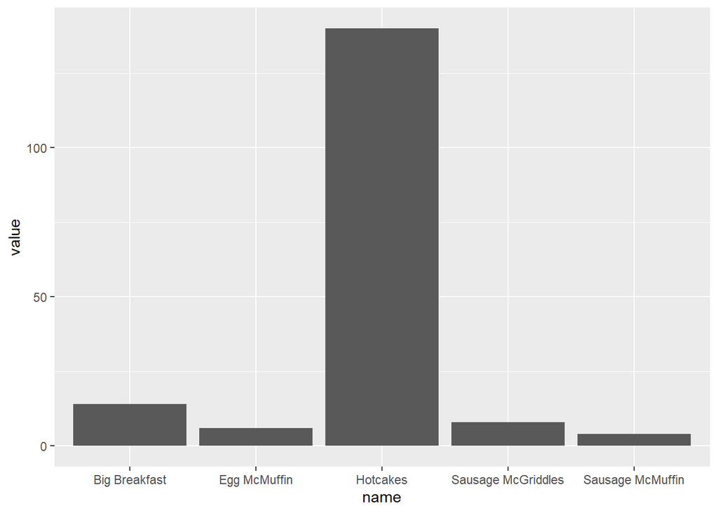

```r
ggplot(data, aes(x=name, y=value)) +
  geom_bar(stat = "identity")
```